# Random Graphs

Random graphs are an extension of graph theory and probability theory in mathematics, and refer to graphs created using random processes. These have wide applications, including power grids, food webs, and protein networks.

Our main focus will however be on the modelling of social networks using random graphs. We shall first look at a sample of Facebook, and identify properties of social networks, then introduce some models of random graphs, and discuss their capability of modelling Facebook.

Finally, we will look at a model the presenter has devised.

All code and tests are written in Python.

## What are Random Graphs?

Random graphs are graphs of nodes or vertices, which are connected by edges. These connections and nodes are generated either by a random distribution, or a random process.

There are many different models that use different methods to create random graphs, to obtain different graphs with different properties.

## What properties do we want?

Different models are suited for different applications.

In our case, we focus on modelling social networks, thus we will be discussing the common characteristics that these networks display.

## Facebook

Facebook is a good example of a social network, and so we shall analyse the properties of a social network using Facebook as an example.

We will be using data of a sample of Facebook collected by Stanford Network Analysis Project (SNAP).

```
Name: Facebook
Type: Graph
Number of nodes: 4039
Number of edges: 88234
Average degree:  43.6910
```

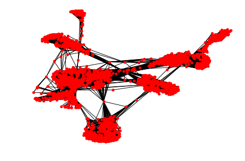

```python
gf = nx.Graph()
with open("facebook_combined.txt") as f:
    edges = f.read().split("\n")
    edges.pop()
    edges = [tuple(map(int, edge.split(" "))) for edge in edges]
gf.add_edges_from(edges)

nx.draw(gf, node_size = 20)
gf.name = "Facebook"
print(nx.info(gf))
```

```
Average clustering coefficient: 0.606
Global clustering coefficient: 0.519
Mean path distance: 3.693
```

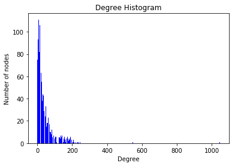

```python
# Facebook
info(gf)
```

## Clustering

A commonly studied property of random graphs is the clustering coefficient.

The local clustering coefficient is the probability that, if you know two friends, the two of them would know each other as well.

This is the clustering coefficient for a specific node $i$, $C_i$, and is calculated as the no. of existing edges between neighbouring nodes divided by the no. of potential edges between neighbouring nodes.

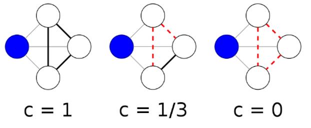

## The Big Picture

Having defined the local clustering coefficient for a single node, we can apply this to the whole graph to get a macro view of its clustering.

One way to do this is by taking the mean of all the local clustering coefficients. Thus we arrive at $C_g = \sum \frac {C_i} {n}$

This is the average clustering coefficient.

## Average vs Global

Another commonly used measure for clustering is transitivity, or the global clustering coefficient. This is a weighted average of the local clustering coefficient, where each $C_i$ is multiplied by ${k_i} \choose {2}$, where $k_i$ is the degree of the node $i$, the number of nodes it is connected to.

Transitivity places more weight on higher degree nodes, which are commonly called "hubs", while the average clustering coefficient places equal weight on all nodes.

## It's a Small World

Researchers often say that we live in a small world. This means that we can reach out to almost anyone in the world with just a few connections. This theory is popularised as the six degrees of separation.

Small world behaviour in networks is characterised largely by high clustering and a low mean path distance. The path distance between two nodes is the smallest number of edges required to connect the two nodes.

## Degree Distributions

The degree distribution of a graph is a histogram of the degrees of all the nodes in the graph.

## Scale-free degree distribution

For a social network, a scale-free degree distribution is a key property. This means that the degree distribution follows a power law, and is skewed such that there is a very low number of hubs, and a much higher number of nodes with degree close to zero.

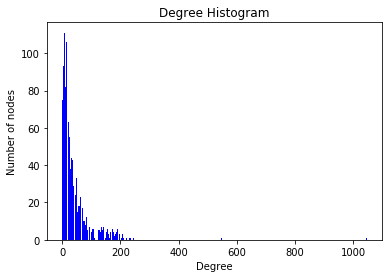

## Basic Models

Now that we have the main ingredients to build a social network, let us look at some of the most fundamental models of random graphs.

## The first model: Erdős–Rényi

This model requires two parameters, $n$ for the number of nodes, and $p$ for the probability of an edge existing between any two nodes independently.

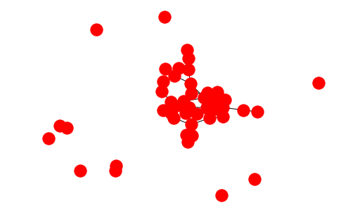

```python
n = 50
p = 0.05
g = nx.erdos_renyi_graph(n, p)
nx.draw(g)
```

```
Average clustering coefficient: 0.027
Global clustering coefficient: 0.024
```

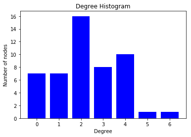

```python
# Erdos-Renyi

info(g)
```

## Watts-Strogatz Model

Also called the small world model, this is a model meant to capture the key elements of a small world network.

The Watts-Strogatz Model requires 3 parameters, $n$, $k$, and $\beta$.

A graph of $n$ nodes is first created, with each node connected to $k/2$ nodes to their immediate left and right. Each edge in the graph is then rewired with probability $\beta$ to a random node.

As such, if $\beta$ is small, the graph forms a structure similar to a lattice, and a few rewired edges are enough to significantly reduce the mean path distance.

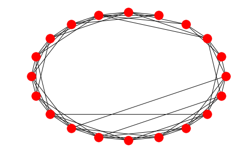

```python
# Watts-Strogatz

n = 20
k = 6
beta = 0.1

g = watts_strogatz(n, k, beta)
nx.draw_shell(g)
```

```
Average clustering coefficient: 0.555
Global clustering coefficient: 0.529
Mean path distance: 2.053
```

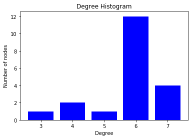

```python
# Watts-Strogatz
info(g)
```

## Barabási-Albert Model

The Barabási-Albert model uses two parameters, $n$ for the number of nodes, and $m$ for the number of edges per node. The model begins with $m$ nodes in an empty graph, and at each next step, a node is added, with m edges connected to other nodes.

The probability of the new node being connected to a node is linearly proportional to the degree of the node. This method is known as linear preferential attachment.

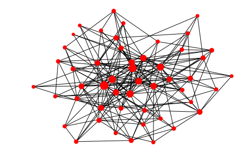

```python
# Barabasi-Albert

n = 50
m = 5

nx.draw(g, node_size = node_sizes)
```

```
Average clustering coefficient: 0.262
Global clustering coefficient: 0.224
Mean path distance: 1.987
```

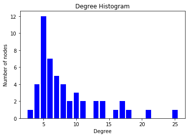

```python
# Barabasi-Albert
info(g)
```

## Scale-free small world

It seems that so far, none of the models we have manage to fit all three of our major requirements: High clustering, low mean path distance, and a scale-free degree distribution.

Fortunately for us, we have a model that mixes them pretty well.

## Klemm-Eguíluz

This is a small world and scale-free model that is a crossover of a high clustering model and the Barabasi-Albert model. Three parameters are required, $n$, $m$, and $\mu$.

1. It begins with a connected graph of $m$ number of active nodes, and a new node is added in each time step.
2. The new node has $m$ edges added to the $m$ active nodes, and each edge is decided, with probability $\mu$, that the edge is rewired to a random node according to linear preferential attachment.
3. The new node is then active, and a random node is deactivated, such that $m$ active nodes remain.

Thus, depending on $\mu$, the graph can be more of a high clustering model, or more like the Barabasi-Albert Model, essentially combining both models.

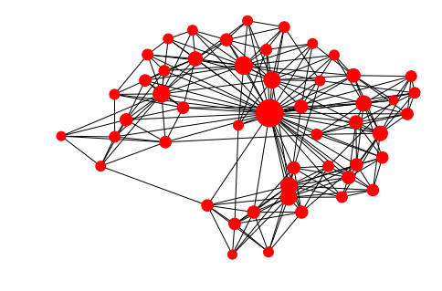

```python
# Klemm-Eguiluz
n = 50
m = 5
mu = 0.2

nx.draw(g, node_size = node_sizes)
```

```
Average clustering coefficient: 0.663
Global clustering coefficient: 0.432
Mean path distance: 1.922
```

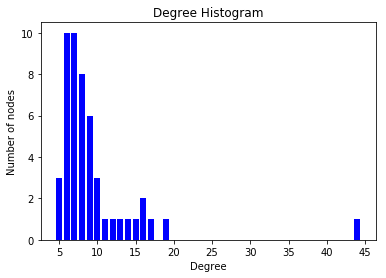

```python
# Klemm-Eguiluz
info(g)
```

## Facing Facebook

Now it's time for our models to challenge Facebook.

Facebook is a good example of a social network. High clustering coefficients of 0.5-0.6, low mean path distance of 3.69, and a scale-free degree distribution.

Obviously, our earliest models would not be able to model Facebook well, because they lack at least one of these properties. But how will the Klemm-Eguiluz model fare?

```
Name: Klemm-Eguiluz
Type: Graph
Number of nodes: 4039
Number of edges: 88605
Average degree:  43.8747
```

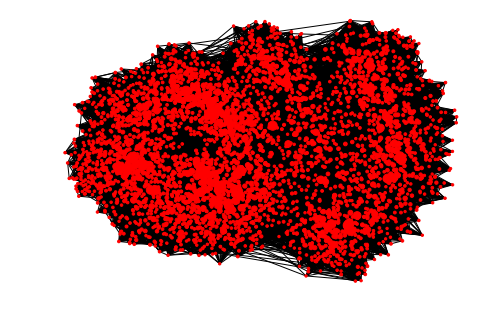

```python
n = 4039
m = 22
mu = 0.1

nx.draw(g, node_size = node_sizes)
g.name = "Klemm-Eguiluz"
print(nx.info(g))
```

```
Average clustering coefficient: 0.58
Global clustering coefficient: 0.319
Mean path distance: 2.826
```

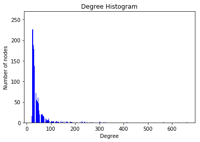

```python
# Klemm-Eguiluz
info(g)
```

Well, it kind of met the main properties that we are looking for. A decent amount of clustering, nice mean path distance, and a scale-free degree distribution.

However, the graph itself is also noticeably different. While it is possible to split the nodes in Facebook into certain blocks, the Klemm-Eguiluz model looks like a giant mess.

[figure not shown]

### SIR

We might not be able to find perfect model for our social network yet, but let us see if they can act in a similar way to Facebook.

In social networks, data and information is constantly exchanged. People spread information to their friends, family, who spread it on to their friends and family, and so on.

To analyse this, we have the Susceptible-Infected-Recovered (SIR) Model.

Nodes are in one of three states: susceptible, infected, or recovered. All nodes begin in the susceptible state. A few are infected, then at every time step, the neighbours of the infected nodes are infected with probability $p_1$, and the infected nodes recover with probability $p_2$. Once all the nodes are recovered, the model ends.

While the most common use of this is to model the spread of infectious diseases, we will apply this to our random graphs to analyse the spread of information, and the properties of random graphs that are more significant here.

```
SIR model of graph after 0 time steps:
```

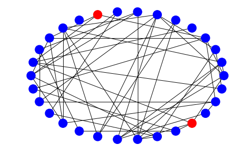

```python
g = nx.erdos_renyi_graph(30, 0.1)
p1, p2, p_init = 0.8, 0.3, 0.1

i_plot, r_plot, s_plot, state, t = sir_init(g, p1, p2, p_init)
```

```
SIR model of graph after 1 time steps:
```

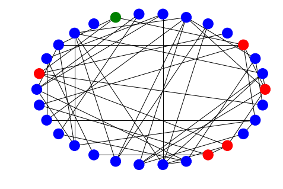

```python
state, t = sir_step(state, t)
```

```
SIR model of graph after 2 time steps:
```

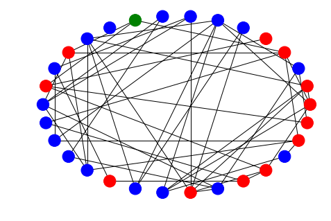

```python
state, t = sir_step(state, t)
```

```
SIR model of graph after 3 time steps:
```

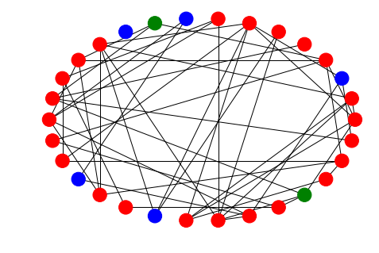

```python
state, t = sir_step(state, t)
```

```
SIR model of graph after 4 time steps:
```

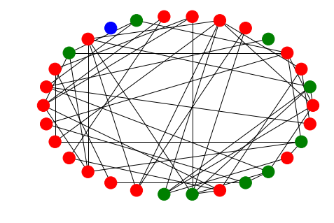

```python
state, t = sir_step(state, t)
```

```
SIR model of graph after 5 time steps:
```

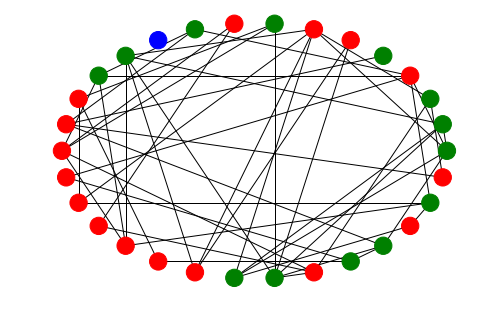

```python
state, t = sir_step(state, t)
```

```
SIR model of graph after 6 time steps:
```

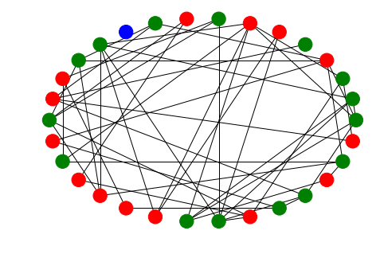

```python
state, t = sir_step(state, t)
```

```
SIR model of graph after 7 time steps:
```

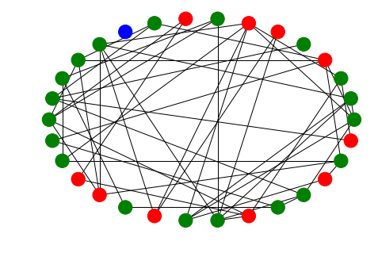

```python
state, t = sir_step(state, t)
```

## SIR Facebook

To determine how closely the different models can simulate the spread of information in Facebook, we will compare the graph of infected nodes over time during an infection, under the same conditions, and by matching the properties of the sample as much as possible.

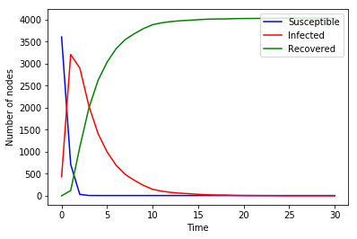

```python
sir_plot(gf, p1, p2, p_init, 30)
```

We will compare the graphs of the proportion of infected nodes over time with the individual models one at a time, and calculate the mean squared error over thirty trials to quantify the deviation of the model in its simulation.

The mean squared error will be calculated for all combinations of p1 and p2 from 0.1 to 0.9, with intervals of 0.1.

Thus, a total of 81 mean squared error values will be collected for each model, and averaged to give a measure of how much error there is.

## SIR Facebook

We will first conduct this process on Facebook, and compare it's SIR simulation with itself, to generate a standard for the amount of error.

For the different values of p1 and p2, the mean error is consistently lower than 0.01, and the overall average is 0.00880.

### Erdős–Rényi

Overall error: 0.0482

[figure not shown]

### Watts-Strogatz

Overall error: 0.0220

[figure not shown]

### Barabási-Albert

Overall error: 0.0553

[figure not shown]

### Klemm-Eguíluz

Overall error: 0.0447

[figure not shown]

Surprisingly, the model that had the smallest overall error is the Watts-Strogatz model, which has high clustering, but lacks a scale-free degree distribution.

The Barabasi-Albert model, being the opposite with scale-free degree distribution and lacking high clustering, did not do so well.

The Klemm-Eguiluz model, which has both high clustering and scale-free degree distribution, had a higher overall error as well.

This seems to suggest that while clustering is an important property for the SIR model in social networks, there are other factors that significantly affect the results as well.

## A new model?

In any case, the current models that we have looked at so far do not seem to fit Facebook very well.

There are a few differences that distinguish Facebook from the models that we have, and one of these is the presence of blocks or clusters of nodes in the graph.

Most of the models that we have drawn simply look like a giant group of nodes all together.

Perhaps there is some way to obtain a graph that doesn't look like that?

## Stochastic Block Model

Stochastic block models are random graphs formed by first dividing the available nodes into groups, then connecting the nodes using different values of $p_1$ and $p_2$ to increase the connections within groups, and to sparsely connect nodes in different groups.

As a result, blocks or clusters are formed, with few connections to other clusters.

```
Number of clusters: 7
```

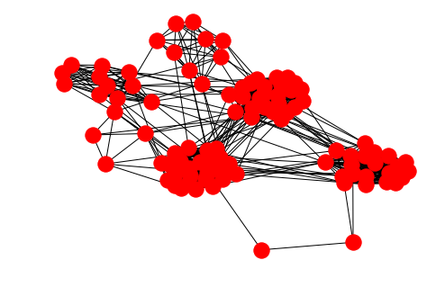

```python
n = 100
p1 = 0.8
p2 = 0.05
nx.draw(block(n, p1, p2))
```

## Geometric Graphs

Geometric random graphs are formed by a different process compared to the other models.

The model begins by placing nodes over the graph. Then all node-pairs that have an Euclidean distance less than a certain critical value would be connected with an edge.

As such, nodes would be connected to every other node within a certain radius, and no other nodes.

## Chang-Chang Model

A model inspired from block models and geometric graphs. It has five parameters, $n$, $k$, $\chi$, $\phi$, $\delta$.

The graph is created by first adding $\chi$ nodes with random coordinates. $\chi$ is the number of clusters and these nodes are the cluster 'bases' that other nodes will be concentrated around.

At every time step, a new node is added. This new node is grouped into one of the $\chi$ clusters, and is added with random coordinates scattered around the cluster base.

A number of edges are then added to the node. These edges will be connected to other nodes as well, and the probability of it connecting to a node is inversely proportional to the Euclidean distance between the two points.

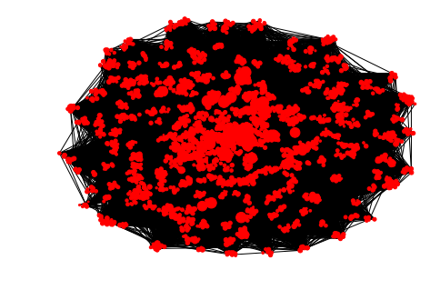

```python
n = 4039
k = 44
phi = 2
chi = 400
delta = 30

pos = nx.get_node_attributes(g, 'pos')
nx.draw(g, pos, node_size = node_sizes)
```

```
Average clustering coefficient: 0.619
Global clustering coefficient: 0.035
Mean path distance: 2.203
```

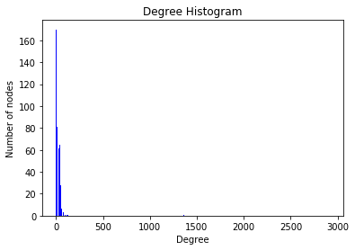

```python
info(g)
```

## Chang-Chang Characteristics

The proposed model has high average clustering coefficient, but a low transitivity.

Recalling that transitivity is the weighted average of the local clustering coefficients by ${k}\choose{2}$, this suggests that the clustering coefficient of lower degree nodes is much higher than those with higher degrees, the hubs.

The shape of the graph in general, is much messier than Facebook, and indicates that there are too many connections between the clusters.

The degree distribution of the graph is scale-free, and follows a power law. The mean path distance is also low at 2.203.

Overall, while the model may have some features that match Facebook's, it is not an accurate model.

## SIR Chang-Chang

We have looked at the SIR model previously, and how the previous models fare in simulating the spread of information in Facebook. How would our new model perform in this regard?

### Chang-Chang

Overall error = 0.0955

[figure not shown]

## Summary

Random graphs can be used to model social networks as one of its applications.

Social networks would have a few main properties that would be desirable in random graphs. These are mainly a high amount of clustering, a scale-free degree distribution, a low mean path distance.

However, based on the tests done on the SIR model, it appears that there are other factors which are characteristic of social networks that our current models are unable to replicate yet.

The disinct manner of clustering of social networks such as Facebook is also significantly different from the other graphs, and the new proposed model is largely unable to fulfill this requirement as well.

## Acknowledgements

These three months have been a wonderful period of learning and experimentation. It has been an enriching experience to study the various features of random graphs, create a new model, and learn of the endless possibilities with Python.

I would like to thank my mentor, Dr Fedor Duzhin, who has taught me much about the topic from the start, and guided me to approaching the project with greater efficiency and curiosity.

I would like to thank Hwa Chong (Happy 100th) and Dr Ho Shen Yong for helping to provide this opportunity for us to learn in this school, without which I would probably be working at McDonald's as I await enlistment.

I would like to thank my fellow interns, who have been forced to look at a good number of my random graphs, and helped contribute to my new model. This internship would have been much more monotonous without your company and support.

Lastly, I would like to thank everyone for coming here today.